# The Human Immunodeficiency Virus in the African Continent

by John Ferrone

#### Abstract

This report discusses the nature of HIV, primarily in Africa, which is the region with the largest amount of data and the highest levels of HIV seen throughout the world, regardless of many other statistics. The purpose of this report is to determine if there is any correlation between the proportion of the population of HIV with factors such as the access to basic drinking water, the education expenditure as a percentage of the GDP, or the rural population as a percentage of the total population. It was found the casualties of HIV were much more significant, such as the percentage of children with HIV as well as orphans is much higher in Africa. Despite this, much of the initial ideas regarding this topic were proven to be incorrect.

## Introduction

### Background

The human immunodeficiency virus, or HIV, first rose to prevelance in the 1970s after it made the jump from chimpanzees to humans. While this virus has likely existed for centuries before it became it was discovered in humans, it was only brought to international attention more recently and has been heavily and harmfully associated with homosexual populations. This is an innacurate association though, as this virus spreads with little care for the host. While initial explorations of the data focused on the entire world, this shifted towards primarily towards Africa as this region had the most consistent and complete data. Africa as a whole is different than the rest of the world when it comes to HIV. The proportion of the world living with HIV is estimated to be about 0.7%, while the proportion of Africa is closer to 5%, a drastically higher number.

The collection of this data was overseen and performed by the World Bank Group and published publically on their website. It includes data for the majority of the world but in each analysis performed there are numerous countries that have been excluded from analysis due to missing data.

### Aims

Certain columns will also be removed in order to maximize the size of the dataset as too many variables with missing values leads to a large number of rows which can not be used. Following this, the data will be tidied further before regression is performed to determine how they act as indicators for the percentage of the population with HIV. Finally, the principle components will also be separated out to confirm any findings and see if there is anything else that can be determined from the data set.

### Datasets

The data is made up of a series of different measurements in order to cover a multitude of potential indicators of HIV. The observational units in this situation are the countries while the primary data points this report will focus on are `hiv_percentage`, `child_hiv`, and `orphan_pop`. These are explained in more detail in the table below. This data is intended to be representative of the populations of each country and the world as a whole. Due to the diverse nature of this data set, it is hard to make an inference about any individual region of the world, and instead it can be used to model individual regions or perhaps show what other regions have that suffering regions do now. The methods through which The World Bank has collected this data is not made clear, but this should most likely be considered census data and its scope is the surveyed populations of the world.

> Table 1: variable descriptions for each column that was analyzed

| Name | Variable Description | Types | Units of Measurement |
| --- | --- | --- | --- |
| region | the country's continent | String | Continent |
| subregion | the country's regional location | String | Region |
| country | the country which is represented in the data | String | Country |
| hiv_percentage | the percentage of adults with HIV | Numeric | % |
| child_hiv | the percentage of children with HIV | Numeric | % |
| education_exp | the yearly expenditure on education per capita | Numeric | % |
| basic_water | population that has access to basic water resources | Numeric | % |
| open_def | population that practices open defecation | Numeric | % |
| unemployment | population that is not currently employed | Numeric | % |
| health_exp | the yearly expenditure on health per capita | Numeric | % |
| orphan_pop | the percentage of the child population that is orphaned | Numeric | % |
| rural_pop | the percentage of the population that lives in rural areas | Numeric | % |
| urban_pop | the percentage of the population that lives in urban areas | Numeric | % |

### Methods

Upon beginning to work with the data, it became clear it needed to be tidied quite a bit before it was fit for analysis. The data had to be pivoted and given names that were clearer, as well as many of the population counts being converted to proportions. In order to represent the data by continent, a United Nations data set containing each country and its respective region and subregion was merged with the original data. Initial explorations began with scatter and bar plots, as well as a correlation matrix in order to see if any values were obviously correlated. The primary focus was to compare `hiv_percentage` with variables such as `child_hiv`, `education_exp`, `health_exp`, `orphan_pop`, and `rural_pop`.

Linear regression was then performed to determine the more influential data points. This was then repeated for just the African continent in order to determine if the variables factored in differently for what seemed to be the most affected continent. This yield interesting, but expected results. Finally principle component analysis would yield results about what clusters of variables seemed to influence the data most significantly, as well as some outliers which seemed to be influenced strongly by both clusters. This in particular was a bit more interesting, as it suggested that other variables may have factored more heavily into the prevalance of HIV than the other methods.

> Table 2: example rows of The World Bank's health data

|  | region | subregion | country | education_exp | hiv_percentage | basic_water | child_hiv | open_defec | health_exp | unemployment | rural_pop | urban_pop | orphan_pop |
| --- | --- | --- | --- | --- | --- | --- | --- | --- | --- | --- | --- | --- | --- |
| 0 | Africa | Northern Africa | Algeria | 0.0586635 | 0.001 | 0.940374 | 5.18407e-05 | 0.00415795 | 0.0616303 | 0.1042 | 0.27371 | 0.72629 | 0.00011782 |
| 1 | Africa | Sub-Saharan Africa | Burundi | 0.0507865 | 0.011 | 0.614606 | 0.00216323 | 0.0260776 | 0.0824477 | 0.01587 | 0.86968 | 0.13032 | 0.0169125 |
| 2 | Africa | Sub-Saharan Africa | Djibouti | 0.0362774 | 0.009 | 0.759369 | 0.00264464 | 0.165002 | 0.0226254 | 0.26189 | 0.22223 | 0.77777 | 0.0275042 |
| 3 | Africa | Sub-Saharan Africa | Ethiopia | 0.0506868 | 0.01 | 0.466385 | 0.00116736 | 0.227702 | 0.0330819 | 0.02318 | 0.79237 | 0.20763 | 0.00808172 |
| 4 | Africa | Sub-Saharan Africa | Kenya | 0.0530625 | 0.045 | 0.602717 | 0.00479333 | 0.0938947 | 0.0430564 | 0.04249 | 0.7297 | 0.2703 | 0.0391292 |

## Results

### Initial Explorations

The initial explorations of the data were focused on finding a potential relationship or region to explore further. After plotting scatterplots of an assortment of variables, it quickly became apparent that the variables were for the most part on two separate scales. There was a much lower scale throughout much of the world, and the much more drastic one seen in Africa.

> Figure 1: scatterplots of variables against `hiv_percentage`

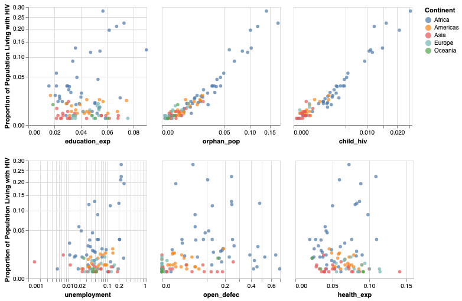

The density plot of `hiv_percentage` continues to support this, as it quickly becomes clear that Africa's density curve does not follow the density barplot created for the world. The right-hand plot confirms this, as it is a density plot of `hiv_percentage` in Africa. There is also a clear distinction between the two subregions as seen by the density lines overlaid on top of the barplot. The `Northern Africa` region follows the same trend as the rest of the world, while the `Sub-Saharan Africa` region seems to be what is causing such a difference between Africa and the rest of the world.

> Figure 2: density plot with the density curve of Africa overlaid on top

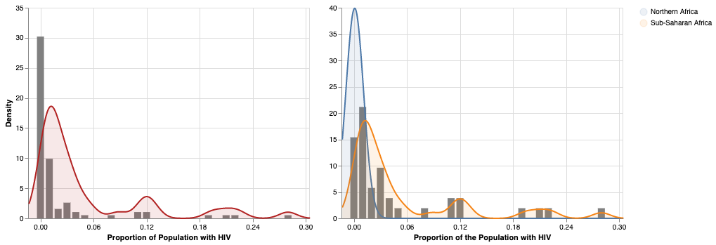

### Africa

> Figure 3: the 20 countries with the highest proportion of their population with HIV

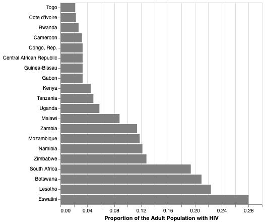

After some further investigation into Eswatini, they have the highest levels of HIV amongst children (2.5% of the population between the ages 0-14) and 14% of the child population is orphaned. Their education and health expenditures are not large, but there are a number of nations which spend a smaller proportion of their GDP on expenditures without seeing a significant increase in the presence of HIV. This leads to the next step, which is to see which variables seem to have the most significant affect on `hiv_percentage`.

> Table 3: linear regression with `hiv_percentage` as the response for the African continent

|  | estimate | standard error |
| --- | --- | --- |
| intercept | 0 | 0.026188 |
| education_exp | 0.256025 | 0.176998 |
| basic_water | 0.033237 | 0.027872 |
| child_hiv | 5.76602 | 1.00586 |
| open_defec | 0.000143 | 0.000137 |
| health_exp | -0.110886 | 0.109393 |
| unemployment | 0.035903 | 0.054558 |
| rural_pop | 0.022193 | 0.022307 |
| orphan_pop | 0.802298 | 0.138601 |
| error variance | 8.3e-05 | nan |

Based on this table, and what is often consistent in the scatterplots, the biggest indicators of a high level of HIV in the population of Africa are `child_hiv` and `orphan_pop`. Unfortunately in this case rather than indicators they are likely the casualty of the high populations with HIV. It is not guaranteed, but possible for a mother to pass HIV to their baby while it is in the womb. There are treatments available which can prevent this, but in the highly rural African regions it is possible that they will not have access to this healthcare. Additionally, these values have a very linear relationship in Africa, there is a definite trend between higher adult populations with HIV and orphaned children. It is likely that the parents who contract this disease are unable to commit to regular treatment and ultimately succomb to AIDS.

### Principal Component Analysis

Following linear regression, principal component analysis was performed on the variables to see if there were any clusters of correlated variables. *Figure 4* seems to actually prove this to some degree, as it becomes immediately clear that variables are very much clustered together.

> Figure 4: center panel is a scatterplot of PC1 vs. PC2, the red points represent the outliers (left to right), Malawi, Mozambique, Zambia, Namibia, Zimbabwe, Botswana, South Africa, Lesotho, and Eswatini right panel is a loading plot of the two principal components.

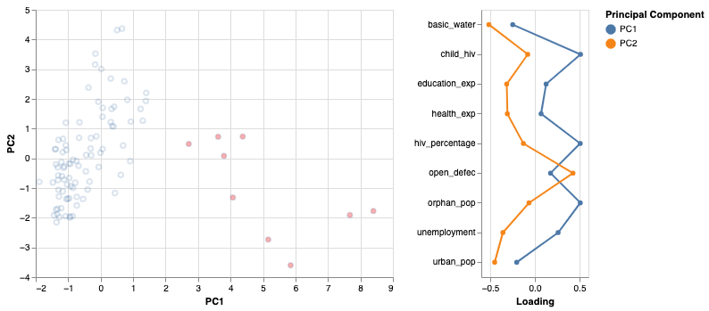

The first principle component seems to be a composition of nations with high levels of `hiv_percentage`, `child_hiv`, and `orphan_pop` with low urban populations and not much access to basic drinking water. The second principle component represents the variation in the data caused by `basic_water`, `open_defec`, and `urban_pop` which seems to suggest this represents nations who have lower levels of HIV but a lack of critical infrastructure. While the majority of nations focus more on the second principal component with lower levels of HIV, those with high levels of HIV are what make the first principal component so prominent in this data. The levels of HIV in Eswatini, Lesotho, and South Africa are so severe even amongst children that they and all of the outliers can be explained differently from the rest of the world.

## Discussion

It is not surprising how devestating this epidemic is to the children of these nations, and there is likely no simple solution to this problem, but a step to improving the situation would be universal access to safe drinking water. These nations likely also need to reevaluate how they spend the their health and education expenditures when it comes to HIV. Educating their young and trying to end the cycle of spreading HIV to their own children by importing treatments could serve as a potential solution based. While this project initially started as an analysis of HIV on a larger scale, it became clear that Africa was where not only the most data could be found, but the most interesting and unique when compared to the world. After initially looking at density plots of Africa and all of the other nations, Africa contained nearly every data point with more than 1% of the population.

It could have been interesting to find a more complete dataset with all of these values and see if there were any clear trends world-wide. There could also be a separate analysis done with Africa removed, to see if there are any trends between `hiv_percentage` and the variables tested above. It is clear from them that Africa seems to be an outlier in a way, such that it can obsure the other data. If more comprehensive geographic data on this existed as well, it could have been interesting to map out where HIV is most prevalent using a geographic heatmap.